# Practical Machine Learning - Groupware Analysis

Alexander Ondrus

2024-10-06

## Introduction

This exercise is to fulfill the final requirements of the Practical Machine Learning course from the Johns Hopkins University specialization *Data Science: Statistical Machine Learning*, available through Coursera. Using a provided training and testing set taken from data provided by:

> Ugulino, W.; Cardador, D.; Vega, K.; Velloso, E.; Milidiu, R.; Fuks, H. *Wearable Computing: Accelerometers’ Data Classification of Body Postures and Movements*. Proceedings of 21st Brazilian Symposium on Artificial Intelligence. Advances in Artificial Intelligence - SBIA 2012. In: Lecture Notes in Computer Science. , pp. 52-61. Curitiba, PR: Springer Berlin / Heidelberg, 2012. ISBN 978-3-642-34458-9. DOI: 10.1007/978-3-642-34459-6_6.

Our aim is to predict the `classe` variable in the testing set with more than 80% accuracy.

## Load and Explore Data

I use the `lubridate` package to decompose the timestamp data into the month, day, day of the week, hour, and minute of each observation. I exclude the year as it has zero variance.

```r
library(tidyverse)
library(magrittr)
library(caret)
library(lubridate)

training <- read_csv(
  "pml-training.csv",
  na = c("", "NA", "#DIV/0!"),
  guess_max = Inf,
  show_col_types = FALSE
  ) %>%
  mutate(
    cvtd_timestamp = dmy_hm(cvtd_timestamp),
    TimeMonth = month(cvtd_timestamp),
    TimeDay = day(cvtd_timestamp),
    DayOfWeek = wday(cvtd_timestamp),
    TimeHour = hour(cvtd_timestamp),
    TimeMinute = minute(cvtd_timestamp)
  ) %>%
  select(
    -`...1`, -cvtd_timestamp
  )

testing <- read_csv(
  "pml-testing.csv",
  na = c("", "NA", "#DIV/0!"),
  guess_max = Inf,
  show_col_types = FALSE
) %>%
  mutate(
    cvtd_timestamp = dmy_hm(cvtd_timestamp),
    TimeMonth = month(cvtd_timestamp),
    TimeDay = day(cvtd_timestamp),
    DayOfWeek = wday(cvtd_timestamp),
    TimeHour = hour(cvtd_timestamp),
    TimeMinute = minute(cvtd_timestamp)
  ) %>%
  select(
    -`...1`, -cvtd_timestamp
  )
```

### Variables Missing from Testing Data

There are 100 predictors that appear to be summary values of single repititions of the exercise. As none of the testing data has any of these summary variables included, I assume that the testing data are snapshots. From that, I deduce that our model needs to be able to predict only snapshots and so I exclude the summary predictors (and the `new_window` indicator, which takes a single value for the entire test set).

```r
useless_columns <- testing %>%
  select(
    where(~all(is.na(.)))
  ) %>%
    colnames()

training %<>%
  select(-all_of(c(useless_columns, "new_window")))

testing %<>%
  select(-all_of(c(useless_columns, "new_window")))
```

### EDA

For exploratory data analysis, I use the `describe` function from the `Hmisc` package. Because the output is quite long, I’ve left it at the bottom of the page (in the section ‘EDA Output’). Several of the values appear to contain outliers, and the classes we are predicting are imbalanced, but other than that there is nothing of specific interest.

### PCA Separability Test

To see if the classes are separable, I first apply PCA to the training set and examine whether the first two components provide any clear clustering of classes.

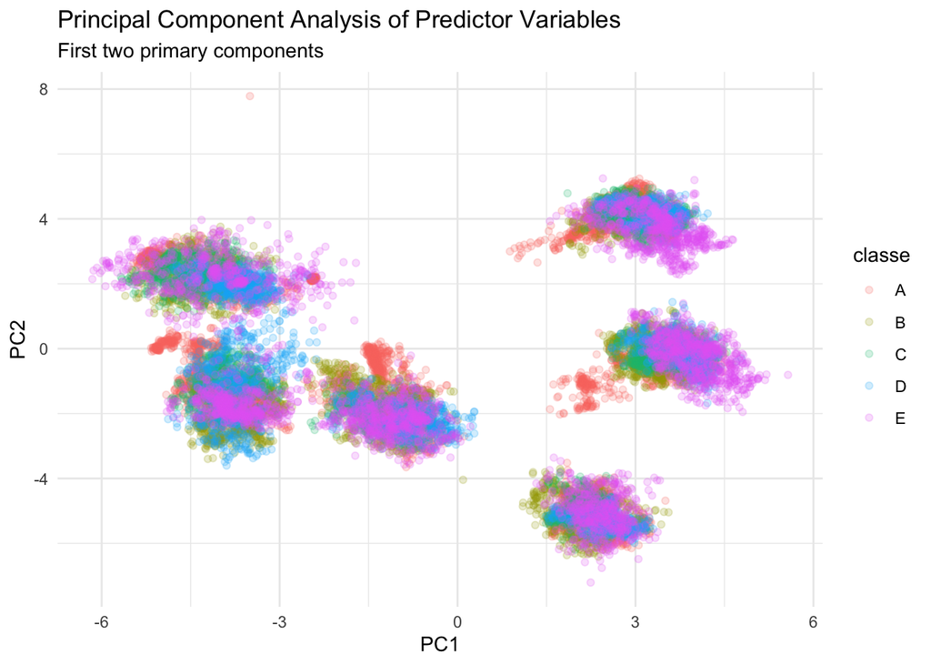

```r
training_pca <- prcomp(
  x = training %>% select(-classe, -user_name),
  scale. = TRUE
)

training_pca_plot <- training_pca$x %>%
  as_tibble() %>%
  mutate(classe = training$classe) %>%
  ggplot(
    aes(
      x = PC1,
      y = PC2,
      colour = classe
    )
  ) +
  geom_point(alpha = 0.2) +
  labs(
    title = "Principal Component Analysis of Predictor Variables",
    subtitle = "First two primary components"
  ) +
  theme_minimal()

plot(training_pca_plot)
```

While there is clearly clustering going on (and it doesn’t appear that the clusters contain each class evenly), the first two components do not contain enough of the variation in the data to explain the cluster assignment.

## Model Selection

Given that there are a large number of quantitative variables and there is clustering in the data, I first tried various discriminant analysis techniques. Linear discriminant analysis was impaired by the co-linearity of the predictors. I attempted to overcome this by shifting to partial least squares discriminant analysis, but the accuracy was not what I had hoped. Flexible discriminant analysis performed better, but was still not optimum.

Rather than attempt ensemble methods, I thought to try fitting a Neural Net. This produced impressive cross-validation accuracy results.

### Neural Net

First, I try a coarse parameter grid with 3-fold cross-validation parameter tuning to narrow my parameter search. The parameter search took hours to complete, so I comment out the code used and load in the completed model when knitting the page.

```r
ctrl <- trainControl(
  method = "cv",
  number = 3,
  classProbs = TRUE,
  savePredictions = TRUE
)

# nnFit <- train(
#   classe ~ .,
#   data = training,
#   method = "nnet",
#   preProc = c("center", "scale", "spatialSign"),
#   tuneGrid = expand.grid(
#     .size = 1:10, .decay = 10^seq(from = -5, to = 0)
#   ),
#   trace = FALSE,
#   maxit = 2000,
#   trControl = ctrl
# )

nnFit <- read_rds("nnFitCoarse.rds")
```

It appears that the best parameters are `size = 7` and `decay = 0.001`.

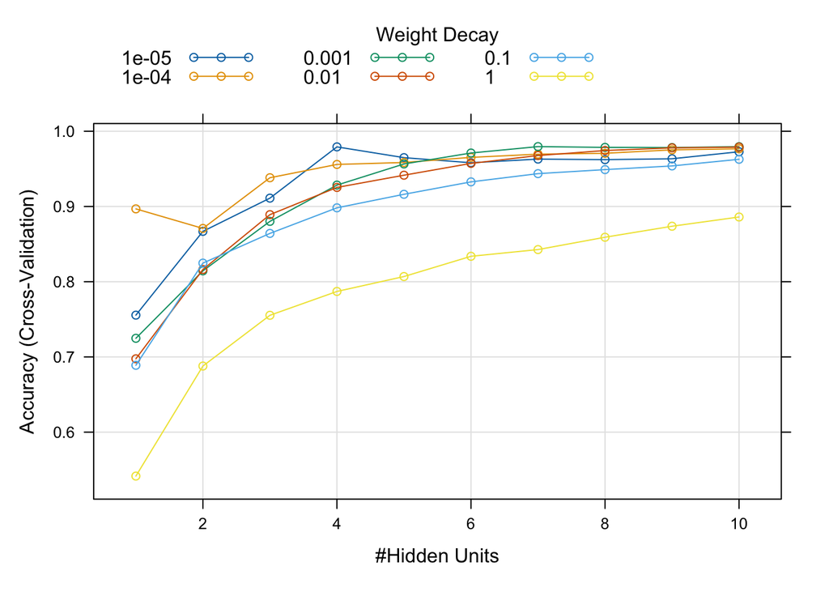

```r
plot(nnFit)
```

To ensure that the variance in cross-validation accuracy estimate is not giving spurious results, I take the top 5 parameter sets and perform 10-fold cross-validation to compare them.

```r
best_5_params <- nnFit$results %>%
  slice_max(
    order_by = Accuracy,
    n = 5
  ) %>%
  select(
    size, decay
  )

ctrl <- trainControl(
  method = "cv",
  number = 10,
  classProbs = TRUE,
  savePredictions = TRUE
)

# nnFit_fine <- train(
#   classe ~ .,
#   data = training,
#   method = "nnet",
#   preProc = c("center", "scale", "spatialSign"),
#   tuneGrid = best_5_params,
#   trace = FALSE,
#   maxit = 2000,
#   trControl = ctrl
# )

nnFit_fine <- read_rds("nnFitFine.rds")
```

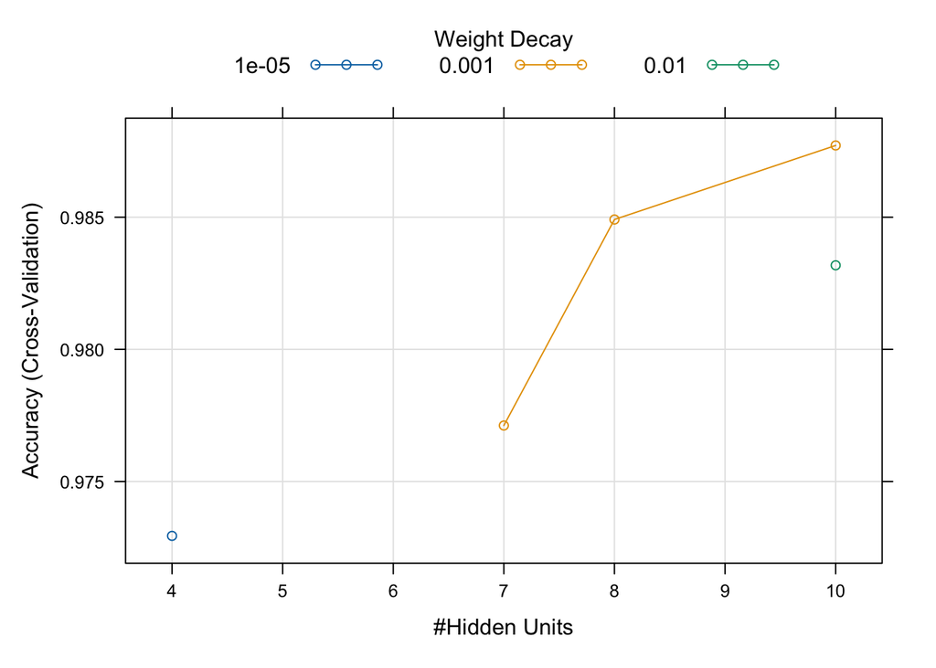

```r
plot(nnFit_fine)
```

We see that the the best fit parameters are `size = 10` and `decay = 0.001`.

## Generating Predictions

Now that I have trained the model, all that remains to do is to generate the predictions:

```r
test_predictions <- predict(
  nnFit_fine,
  newdata = testing
)
```

### EDA Output

```r
testing_describe_Hmisc <- Hmisc::describe(training)
Hmisc::html(testing_describe_Hmisc)
```

training  
62 Variables 19622 Observations

user_name

| n | missing | distinct |
| --- | --- | --- |
| 19622 | 0 | 6 |

```
 Value        adelmo carlitos  charles   eurico   jeremy    pedro
 Frequency      3892     3112     3536     3070     3402     2610
 Proportion    0.198    0.159    0.180    0.156    0.173    0.133
```

raw_timestamp_part_1

```
         n   missing  distinct      Info      Mean       Gmd       .05       .10
     19622         0       837         1 1.323e+09    225850 1.322e+09 1.322e+09
       .25       .50       .75       .90       .95
 1.323e+09 1.323e+09 1.323e+09 1.323e+09 1.323e+09
```

```
 Value      1322485000 1322670000 1322830000 1322835000 1323080000 1323090000
 Frequency        3070       3402       3892       3536       3112        723
 Proportion      0.156      0.173      0.198      0.180      0.159      0.037

 Value      1323095000
 Frequency        1887
 Proportion      0.096
```

For the frequency table, variable is rounded to the nearest 5000

raw_timestamp_part_2

| n | missing | distinct | Info | Mean | Gmd | .05 | .10 | .25 | .50 | .75 | .90 | .95 |
| --- | --- | --- | --- | --- | --- | --- | --- | --- | --- | --- | --- | --- |
| 19622 | 0 | 16783 | 1 | 500656 | 332807 | 48389 | 100343 | 252912 | 496380 | 751891 | 900367 | 950649 |

lowest : 294 301 307 309 312 , highest: 998716 998741 998749 998750 998801

num_window

| n | missing | distinct | Info | Mean | Gmd | .05 | .10 | .25 | .50 | .75 | .90 | .95 |
| --- | --- | --- | --- | --- | --- | --- | --- | --- | --- | --- | --- | --- |
| 19622 | 0 | 858 | 1 | 430.6 | 286.2 | 44 | 88 | 222 | 424 | 644 | 780 | 821 |

lowest : 1 2 3 4 5 , highest: 860 861 862 863 864

roll_belt

| n | missing | distinct | Info | Mean | Gmd | .05 | .10 | .25 | .50 | .75 | .90 | .95 |
| --- | --- | --- | --- | --- | --- | --- | --- | --- | --- | --- | --- | --- |
| 19622 | 0 | 1330 | 1 | 64.41 | 65.45 | -0.20 | 0.53 | 1.10 | 113.00 | 123.00 | 129.00 | 139.00 |

lowest : -28.9 -28.8 -28.6 -28.4 -28.3 , highest: 158 159 160 161 162

pitch_belt

| n | missing | distinct | Info | Mean | Gmd | .05 | .10 | .25 | .50 | .75 | .90 | .95 |
| --- | --- | --- | --- | --- | --- | --- | --- | --- | --- | --- | --- | --- |
| 19622 | 0 | 1840 | 1 | 0.3053 | 22.92 | -43.60 | -42.10 | 1.76 | 5.28 | 14.90 | 25.40 | 26.20 |

lowest : -55.8 -54.9 -54.7 -54.4 -53.9 , highest: 59.9 60 60.1 60.2 60.3

yaw_belt

| n | missing | distinct | Info | Mean | Gmd | .05 | .10 | .25 | .50 | .75 | .90 | .95 |
| --- | --- | --- | --- | --- | --- | --- | --- | --- | --- | --- | --- | --- |
| 19622 | 0 | 1957 | 1 | -11.21 | 99.34 | -93.5 | -92.9 | -88.3 | -13.0 | 12.9 | 165.0 | 168.0 |

lowest : -180 -179 -178 -177 -176 , highest: 175 176 177 178 179

total_accel_belt

| n | missing | distinct | Info | Mean | Gmd | .05 | .10 | .25 | .50 | .75 | .90 | .95 |
| --- | --- | --- | --- | --- | --- | --- | --- | --- | --- | --- | --- | --- |
| 19622 | 0 | 29 | 0.976 | 11.31 | 8.349 | 2 | 3 | 3 | 17 | 18 | 20 | 21 |

lowest : 0 1 2 3 4 , highest: 25 26 27 28 29

gyros_belt_x

| n | missing | distinct | Info | Mean | Gmd | .05 | .10 | .25 | .50 | .75 | .90 | .95 |
| --- | --- | --- | --- | --- | --- | --- | --- | --- | --- | --- | --- | --- |
| 19622 | 0 | 140 | 0.998 | -0.005592 | 0.2029 | -0.45 | -0.39 | -0.03 | 0.03 | 0.11 | 0.16 | 0.21 |

lowest : -1.04 -1 -0.98 -0.96 -0.95 , highest: 1.88 1.98 2.02 2.2 2.22

gyros_belt_y

| n | missing | distinct | Info | Mean | Gmd | .05 | .10 | .25 | .50 | .75 | .90 | .95 |
| --- | --- | --- | --- | --- | --- | --- | --- | --- | --- | --- | --- | --- |
| 19622 | 0 | 69 | 0.974 | 0.03959 | 0.08102 | -0.05 | -0.03 | 0.00 | 0.02 | 0.11 | 0.13 | 0.13 |

lowest : -0.64 -0.53 -0.51 -0.48 -0.45 , highest: 0.51 0.56 0.61 0.63 0.64

gyros_belt_z

| n | missing | distinct | Info | Mean | Gmd | .05 | .10 | .25 | .50 | .75 | .90 | .95 |
| --- | --- | --- | --- | --- | --- | --- | --- | --- | --- | --- | --- | --- |
| 19622 | 0 | 169 | 0.997 | -0.1305 | 0.237 | -0.49 | -0.44 | -0.20 | -0.10 | -0.02 | 0.02 | 0.11 |

lowest : -1.46 -1.35 -1.33 -1.3 -1.28 , highest: 1.41 1.44 1.51 1.61 1.62

accel_belt_x

| n | missing | distinct | Info | Mean | Gmd | .05 | .10 | .25 | .50 | .75 | .90 | .95 |
| --- | --- | --- | --- | --- | --- | --- | --- | --- | --- | --- | --- | --- |
| 19622 | 0 | 164 | 0.999 | -5.595 | 30.65 | -42 | -39 | -21 | -15 | -5 | 49 | 51 |

lowest : -120 -83 -82 -81 -80 , highest: 78 79 81 83 85

accel_belt_y

| n | missing | distinct | Info | Mean | Gmd | .05 | .10 | .25 | .50 | .75 | .90 | .95 |
| --- | --- | --- | --- | --- | --- | --- | --- | --- | --- | --- | --- | --- |
| 19622 | 0 | 143 | 0.998 | 30.15 | 31.6 | -1 | 1 | 3 | 35 | 61 | 68 | 71 |

lowest : -69 -65 -54 -41 -38 , highest: 109 121 149 150 164

accel_belt_z

| n | missing | distinct | Info | Mean | Gmd | .05 | .10 | .25 | .50 | .75 | .90 | .95 |
| --- | --- | --- | --- | --- | --- | --- | --- | --- | --- | --- | --- | --- |
| 19622 | 0 | 299 | 1 | -72.59 | 107.3 | -190 | -175 | -162 | -152 | 27 | 42 | 45 |

lowest : -275 -269 -268 -266 -265 , highest: 101 102 103 104 105

magnet_belt_x

| n | missing | distinct | Info | Mean | Gmd | .05 | .10 | .25 | .50 | .75 | .90 | .95 |
| --- | --- | --- | --- | --- | --- | --- | --- | --- | --- | --- | --- | --- |
| 19622 | 0 | 327 | 1 | 55.6 | 65.07 | -4 | 0 | 9 | 35 | 59 | 167 | 173 |

lowest : -52 -49 -48 -46 -45 , highest: 474 476 479 481 485

magnet_belt_y

| n | missing | distinct | Info | Mean | Gmd | .05 | .10 | .25 | .50 | .75 | .90 | .95 |
| --- | --- | --- | --- | --- | --- | --- | --- | --- | --- | --- | --- | --- |
| 19622 | 0 | 298 | 1 | 593.7 | 34.49 | 525.1 | 564.0 | 581.0 | 601.0 | 610.0 | 631.0 | 635.0 |

lowest : 354 359 360 363 365 , highest: 666 667 668 669 673

magnet_belt_z

| n | missing | distinct | Info | Mean | Gmd | .05 | .10 | .25 | .50 | .75 | .90 | .95 |
| --- | --- | --- | --- | --- | --- | --- | --- | --- | --- | --- | --- | --- |
| 19622 | 0 | 457 | 1 | -345.5 | 64.29 | -452 | -431 | -375 | -320 | -306 | -297 | -291 |

lowest : -623 -621 -620 -618 -616 , highest: 284 286 287 289 293

roll_arm

```
        n  missing distinct     Info     Mean      Gmd      .05      .10      .25
    19622        0     2654    0.995    17.83    82.06  -117.00   -70.09   -31.78
      .50      .75      .90      .95
     0.00    77.30   113.00   135.00
```

lowest : -180 -178 -177 -176 -175 , highest: 176 177 178 179 180

pitch_arm

| n | missing | distinct | Info | Mean | Gmd | .05 | .10 | .25 | .50 | .75 | .90 | .95 |
| --- | --- | --- | --- | --- | --- | --- | --- | --- | --- | --- | --- | --- |
| 19622 | 0 | 3087 | 0.995 | -4.612 | 33.98 | -56.0 | -42.6 | -25.9 | 0.0 | 11.2 | 34.6 | 51.1 |

lowest : -88.8 -88.2 -87.9 -87.8 -87.7 , highest: 86.6 86.8 87.1 88.2 88.5

yaw_arm

```
        n  missing distinct     Info     Mean      Gmd      .05      .10      .25
    19622        0     2876    0.995  -0.6188    79.88  -128.00   -92.09   -43.10
      .50      .75      .90      .95
     0.00    45.88   102.00   116.00
```

lowest : -180 -179 -178 -177 -176 , highest: 176 177 178 179 180

total_accel_arm

| n | missing | distinct | Info | Mean | Gmd | .05 | .10 | .25 | .50 | .75 | .90 | .95 |
| --- | --- | --- | --- | --- | --- | --- | --- | --- | --- | --- | --- | --- |
| 19622 | 0 | 66 | 0.999 | 25.51 | 11.93 | 8 | 11 | 17 | 27 | 33 | 38 | 42 |

lowest : 1 2 3 4 5 , highest: 62 63 64 65 66

gyros_arm_x

| n | missing | distinct | Info | Mean | Gmd | .05 | .10 | .25 | .50 | .75 | .90 | .95 |
| --- | --- | --- | --- | --- | --- | --- | --- | --- | --- | --- | --- | --- |
| 19622 | 0 | 643 | 1 | 0.04277 | 2.256 | -3.48 | -2.79 | -1.33 | 0.08 | 1.57 | 2.59 | 3.12 |

lowest : -6.37 -6.36 -6.34 -6.13 -6.12 , highest: 4.7 4.74 4.78 4.82 4.87

gyros_arm_y

| n | missing | distinct | Info | Mean | Gmd | .05 | .10 | .25 | .50 | .75 | .90 | .95 |
| --- | --- | --- | --- | --- | --- | --- | --- | --- | --- | --- | --- | --- |
| 19622 | 0 | 376 | 1 | -0.2571 | 0.9408 | -1.56 | -1.25 | -0.80 | -0.24 | 0.14 | 0.85 | 1.27 |

lowest : -3.44 -3.4 -3.37 -3.32 -3.29 , highest: 2.76 2.78 2.79 2.81 2.84

gyros_arm_z

| n | missing | distinct | Info | Mean | Gmd | .05 | .10 | .25 | .50 | .75 | .90 | .95 |
| --- | --- | --- | --- | --- | --- | --- | --- | --- | --- | --- | --- | --- |
| 19622 | 0 | 248 | 1 | 0.2695 | 0.6239 | -0.67 | -0.43 | -0.07 | 0.23 | 0.72 | 0.95 | 1.10 |

lowest : -2.33 -2.28 -2.17 -2.13 -2.1 , highest: 2.66 2.69 2.95 2.99 3.02

accel_arm_x

| n | missing | distinct | Info | Mean | Gmd | .05 | .10 | .25 | .50 | .75 | .90 | .95 |
| --- | --- | --- | --- | --- | --- | --- | --- | --- | --- | --- | --- | --- |
| 19622 | 0 | 777 | 1 | -60.24 | 205.8 | -289 | -280 | -242 | -44 | 84 | 150 | 245 |

lowest : -404 -383 -377 -371 -367 , highest: 430 431 434 435 437

accel_arm_y

| n | missing | distinct | Info | Mean | Gmd | .05 | .10 | .25 | .50 | .75 | .90 | .95 |
| --- | --- | --- | --- | --- | --- | --- | --- | --- | --- | --- | --- | --- |
| 19622 | 0 | 537 | 1 | 32.6 | 125.7 | -134 | -102 | -54 | 14 | 139 | 173 | 199 |

lowest : -318 -315 -302 -301 -286 , highest: 296 297 299 303 308

accel_arm_z

| n | missing | distinct | Info | Mean | Gmd | .05 | .10 | .25 | .50 | .75 | .90 | .95 |
| --- | --- | --- | --- | --- | --- | --- | --- | --- | --- | --- | --- | --- |
| 19622 | 0 | 792 | 1 | -71.25 | 147.6 | -340 | -249 | -143 | -47 | 23 | 75 | 116 |

lowest : -636 -630 -629 -613 -612 , highest: 239 242 245 271 292

magnet_arm_x

| n | missing | distinct | Info | Mean | Gmd | .05 | .10 | .25 | .50 | .75 | .90 | .95 |
| --- | --- | --- | --- | --- | --- | --- | --- | --- | --- | --- | --- | --- |
| 19622 | 0 | 1339 | 1 | 191.7 | 502.6 | -422 | -403 | -300 | 289 | 637 | 728 | 744 |

lowest : -584 -580 -579 -578 -576 , highest: 777 778 779 780 782

magnet_arm_y

| n | missing | distinct | Info | Mean | Gmd | .05 | .10 | .25 | .50 | .75 | .90 | .95 |
| --- | --- | --- | --- | --- | --- | --- | --- | --- | --- | --- | --- | --- |
| 19622 | 0 | 872 | 1 | 156.6 | 229.3 | -200 | -141 | -9 | 202 | 323 | 391 | 435 |

lowest : -392 -386 -384 -381 -377 , highest: 577 578 580 582 583

magnet_arm_z

| n | missing | distinct | Info | Mean | Gmd | .05 | .10 | .25 | .50 | .75 | .90 | .95 |
| --- | --- | --- | --- | --- | --- | --- | --- | --- | --- | --- | --- | --- |
| 19622 | 0 | 1265 | 1 | 306.5 | 343.4 | -420.0 | -242.0 | 131.2 | 444.0 | 545.0 | 597.0 | 620.0 |

lowest : -597 -596 -595 -590 -586 , highest: 685 687 690 693 694

roll_dumbbell

```
        n  missing distinct     Info     Mean      Gmd      .05      .10      .25
    19622        0    16523        1    23.84    76.94  -110.15   -99.51   -18.49
      .50      .75      .90      .95
    48.17    67.61   102.74   116.28
```

lowest : -153.714 -153.51 -152.827 -152.425 -152.033 , highest: 151 151.352 152.084 153.378 153.546

pitch_dumbbell

| n | missing | distinct | Info | Mean | Gmd | .05 | .10 | .25 | .50 | .75 | .90 | .95 |
| --- | --- | --- | --- | --- | --- | --- | --- | --- | --- | --- | --- | --- |
| 19622 | 0 | 16040 | 1 | -10.78 | 41.51 | -56.44 | -51.70 | -40.89 | -20.96 | 17.50 | 38.51 | 51.34 |

lowest : -149.594 -148.5 -137.34 -134.732 -130.105 , highest: 127.934 129.515 129.824 137.025 149.402

yaw_dumbbell

```
        n  missing distinct     Info     Mean      Gmd      .05      .10      .25
    19622        0    16381        1    1.674    94.15 -102.418  -95.474  -77.644
      .50      .75      .90      .95
   -3.324   79.643  121.218  129.065
```

lowest : -150.871 -148.766 -147.113 -146.244 -144.343 , highest: 154.134 154.223 154.516 154.754 154.952

total_accel_dumbbell

| n | missing | distinct | Info | Mean | Gmd | .05 | .10 | .25 | .50 | .75 | .90 | .95 |
| --- | --- | --- | --- | --- | --- | --- | --- | --- | --- | --- | --- | --- |
| 19622 | 0 | 43 | 0.998 | 13.72 | 11.47 | 2 | 2 | 4 | 10 | 19 | 30 | 31 |

lowest : 0 1 2 3 4 , highest: 38 39 40 42 58

gyros_dumbbell_x

| n | missing | distinct | Info | Mean | Gmd | .05 | .10 | .25 | .50 | .75 | .90 | .95 |
| --- | --- | --- | --- | --- | --- | --- | --- | --- | --- | --- | --- | --- |
| 19622 | 0 | 241 | 1 | 0.1611 | 0.4241 | -0.37 | -0.21 | -0.03 | 0.13 | 0.35 | 0.59 | 0.83 |

lowest : -204 -1.99 -1.94 -1.86 -1.85 , highest: 2.07 2.14 2.17 2.2 2.22

gyros_dumbbell_y

| n | missing | distinct | Info | Mean | Gmd | .05 | .10 | .25 | .50 | .75 | .90 | .95 |
| --- | --- | --- | --- | --- | --- | --- | --- | --- | --- | --- | --- | --- |
| 19622 | 0 | 278 | 1 | 0.04606 | 0.499 | -0.80 | -0.48 | -0.14 | 0.03 | 0.21 | 0.56 | 0.92 |

lowest : -2.1 -2.07 -2.06 -2.04 -2.01 , highest: 2.63 2.71 2.73 4.37 52

gyros_dumbbell_z

| n | missing | distinct | Info | Mean | Gmd | .05 | .10 | .25 | .50 | .75 | .90 | .95 |
| --- | --- | --- | --- | --- | --- | --- | --- | --- | --- | --- | --- | --- |
| 19622 | 0 | 206 | 1 | -0.129 | 0.3698 | -0.67 | -0.49 | -0.31 | -0.13 | 0.03 | 0.20 | 0.33 |

lowest : -2.38 -2.3 -2.08 -2 -1.95 , highest: 1.61 1.67 1.72 1.87 317

accel_dumbbell_x

| n | missing | distinct | Info | Mean | Gmd | .05 | .10 | .25 | .50 | .75 | .90 | .95 |
| --- | --- | --- | --- | --- | --- | --- | --- | --- | --- | --- | --- | --- |
| 19622 | 0 | 425 | 1 | -28.62 | 71.42 | -145 | -140 | -50 | -8 | 11 | 29 | 53 |

lowest : -419 -237 -236 -235 -234 , highest: 217 219 224 234 235

accel_dumbbell_y

| n | missing | distinct | Info | Mean | Gmd | .05 | .10 | .25 | .50 | .75 | .90 | .95 |
| --- | --- | --- | --- | --- | --- | --- | --- | --- | --- | --- | --- | --- |
| 19622 | 0 | 466 | 1 | 52.63 | 91.48 | -61.0 | -41.0 | -8.0 | 41.5 | 111.0 | 161.0 | 194.0 |

lowest : -189 -182 -181 -179 -176 , highest: 299 300 302 310 315

accel_dumbbell_z

| n | missing | distinct | Info | Mean | Gmd | .05 | .10 | .25 | .50 | .75 | .90 | .95 |
| --- | --- | --- | --- | --- | --- | --- | --- | --- | --- | --- | --- | --- |
| 19622 | 0 | 410 | 1 | -38.32 | 122.2 | -206 | -197 | -142 | -1 | 38 | 88 | 98 |

lowest : -334 -319 -284 -273 -272 , highest: 314 315 316 317 318

magnet_dumbbell_x

| n | missing | distinct | Info | Mean | Gmd | .05 | .10 | .25 | .50 | .75 | .90 | .95 |
| --- | --- | --- | --- | --- | --- | --- | --- | --- | --- | --- | --- | --- |
| 19622 | 0 | 1128 | 1 | -328.5 | 317.4 | -579.0 | -564.0 | -535.0 | -479.0 | -304.0 | 445.9 | 520.0 |

lowest : -643 -639 -638 -637 -635 , highest: 579 582 583 584 592

magnet_dumbbell_y

| n | missing | distinct | Info | Mean | Gmd | .05 | .10 | .25 | .50 | .75 | .90 | .95 |
| --- | --- | --- | --- | --- | --- | --- | --- | --- | --- | --- | --- | --- |
| 19622 | 0 | 844 | 1 | 221 | 303.6 | -562 | -516 | 231 | 311 | 390 | 500 | 551 |

lowest : -3600 -744 -742 -741 -740 , highest: 629 630 631 632 633

magnet_dumbbell_z

| n | missing | distinct | Info | Mean | Gmd | .05 | .10 | .25 | .50 | .75 | .90 | .95 |
| --- | --- | --- | --- | --- | --- | --- | --- | --- | --- | --- | --- | --- |
| 19622 | 0 | 676 | 1 | 46.05 | 151.4 | -152 | -93 | -45 | 13 | 95 | 294 | 345 |

lowest : -262 -250 -249 -248 -245 , highest: 442 443 447 451 452

roll_forearm

```
         n   missing  distinct      Info      Mean       Gmd       .05       .10
     19622         0      2176     0.992     33.83     120.9 -175.0000 -154.0000
       .25       .50       .75       .90       .95
   -0.7375   21.7000  140.0000  162.0000  174.0000
```

lowest : -180 -179 -178 -177 -176 , highest: 176 177 178 179 180

pitch_forearm

```
        n  missing distinct     Info     Mean      Gmd      .05      .10      .25
    19622        0     2915    0.992    10.71    30.31   -51.40   -19.20     0.00
      .50      .75      .90      .95
     9.24    28.40    46.10    54.00
```

lowest : -72.5 -72.4 -72.1 -71.6 -71.4 , highest: 87.5 87.9 88.4 88.7 89.8

yaw_forearm

```
        n  missing distinct     Info     Mean      Gmd      .05      .10      .25
    19622        0     1991    0.992    19.21    117.7   -153.0   -138.0    -68.6
      .50      .75      .90      .95
      0.0    110.0    151.0    163.0
```

lowest : -180 -179 -178 -177 -176 , highest: 176 177 178 179 180

total_accel_forearm

| n | missing | distinct | Info | Mean | Gmd | .05 | .10 | .25 | .50 | .75 | .90 | .95 |
| --- | --- | --- | --- | --- | --- | --- | --- | --- | --- | --- | --- | --- |
| 19622 | 0 | 70 | 0.999 | 34.72 | 11.05 | 15 | 23 | 29 | 36 | 41 | 47 | 50 |

lowest : 0 1 2 3 4 , highest: 68 73 78 79 108

gyros_forearm_x

| n | missing | distinct | Info | Mean | Gmd | .05 | .10 | .25 | .50 | .75 | .90 | .95 |
| --- | --- | --- | --- | --- | --- | --- | --- | --- | --- | --- | --- | --- |
| 19622 | 0 | 298 | 1 | 0.158 | 0.6965 | -0.75 | -0.55 | -0.22 | 0.05 | 0.56 | 1.04 | 1.24 |

lowest : -22 -4.95 -3.36 -3.08 -2.99 , highest: 3.1 3.26 3.48 3.52 3.97

gyros_forearm_y

| n | missing | distinct | Info | Mean | Gmd | .05 | .10 | .25 | .50 | .75 | .90 | .95 |
| --- | --- | --- | --- | --- | --- | --- | --- | --- | --- | --- | --- | --- |
| 19622 | 0 | 741 | 1 | 0.07517 | 2.484 | -3.61 | -2.94 | -1.46 | 0.03 | 1.62 | 2.83 | 3.50 |

lowest : -7.02 -6.65 -6.62 -6.54 -6.52 , highest: 6.09 6.1 6.12 6.13 311

gyros_forearm_z

| n | missing | distinct | Info | Mean | Gmd | .05 | .10 | .25 | .50 | .75 | .90 | .95 |
| --- | --- | --- | --- | --- | --- | --- | --- | --- | --- | --- | --- | --- |
| 19622 | 0 | 307 | 1 | 0.1512 | 0.6741 | -0.82 | -0.57 | -0.18 | 0.08 | 0.49 | 0.89 | 1.13 |

lowest : -8.09 -7.94 -6.99 -5.55 -4.28 , highest: 3.35 4.04 4.1 4.31 231

accel_forearm_x

| n | missing | distinct | Info | Mean | Gmd | .05 | .10 | .25 | .50 | .75 | .90 | .95 |
| --- | --- | --- | --- | --- | --- | --- | --- | --- | --- | --- | --- | --- |
| 19622 | 0 | 794 | 1 | -61.65 | 206.3 | -392 | -331 | -178 | -57 | 76 | 188 | 223 |

lowest : -498 -496 -487 -479 -477 , highest: 370 375 381 389 477

accel_forearm_y

| n | missing | distinct | Info | Mean | Gmd | .05 | .10 | .25 | .50 | .75 | .90 | .95 |
| --- | --- | --- | --- | --- | --- | --- | --- | --- | --- | --- | --- | --- |
| 19622 | 0 | 1003 | 1 | 163.7 | 223.9 | -227 | -140 | 57 | 201 | 312 | 395 | 436 |

lowest : -632 -595 -585 -537 -496 , highest: 588 589 590 591 923

accel_forearm_z

| n | missing | distinct | Info | Mean | Gmd | .05 | .10 | .25 | .50 | .75 | .90 | .95 |
| --- | --- | --- | --- | --- | --- | --- | --- | --- | --- | --- | --- | --- |
| 19622 | 0 | 580 | 1 | -55.29 | 155.6 | -222.0 | -209.0 | -182.0 | -39.0 | 26.0 | 175.9 | 199.0 |

lowest : -446 -410 -391 -386 -381 , highest: 275 277 285 287 291

magnet_forearm_x

| n | missing | distinct | Info | Mean | Gmd | .05 | .10 | .25 | .50 | .75 | .90 | .95 |
| --- | --- | --- | --- | --- | --- | --- | --- | --- | --- | --- | --- | --- |
| 19622 | 0 | 1524 | 1 | -312.6 | 386 | -700 | -684 | -616 | -378 | -73 | 128 | 379 |

lowest : -1280 -1270 -1260 -1250 -1240 , highest: 660 661 663 666 672

magnet_forearm_y

| n | missing | distinct | Info | Mean | Gmd | .05 | .10 | .25 | .50 | .75 | .90 | .95 |
| --- | --- | --- | --- | --- | --- | --- | --- | --- | --- | --- | --- | --- |
| 19622 | 0 | 1872 | 1 | 380.1 | 553.2 | -632.9 | -472.9 | 2.0 | 591.0 | 737.0 | 797.0 | 981.0 |

lowest : -896 -892 -890 -885 -882 , highest: 1430 1440 1450 1460 1480

magnet_forearm_z

| n | missing | distinct | Info | Mean | Gmd | .05 | .10 | .25 | .50 | .75 | .90 | .95 |
| --- | --- | --- | --- | --- | --- | --- | --- | --- | --- | --- | --- | --- |
| 19622 | 0 | 1683 | 1 | 393.6 | 390 | -453.0 | -153.9 | 191.0 | 511.0 | 653.0 | 736.0 | 799.0 |

lowest : -973 -966 -964 -963 -962 , highest: 1040 1050 1070 1080 1090

classe

| n | missing | distinct |
| --- | --- | --- |
| 19622 | 0 | 5 |

```
 Value          A     B     C     D     E
 Frequency   5580  3797  3422  3216  3607
 Proportion 0.284 0.194 0.174 0.164 0.184
```

TimeMonth

| n | missing | distinct | Info | Mean | Gmd |
| --- | --- | --- | --- | --- | --- |
| 19622 | 0 | 2 | 0.663 | 11.67 | 0.4421 |

```
 Value         11    12
 Frequency   6472 13150
 Proportion  0.33  0.67
```

TimeDay

| n | missing | distinct | Info | Mean | Gmd |
| --- | --- | --- | --- | --- | --- |
| 19622 | 0 | 4 | 0.912 | 11.8 | 12.15 |

```
 Value          2     5    28    30
 Frequency   7428  5722  3070  3402
 Proportion 0.379 0.292 0.156 0.173
```

For the frequency table, variable is rounded to the nearest 0

DayOfWeek

| n | missing | distinct | Info | Mean | Gmd |
| --- | --- | --- | --- | --- | --- |
| 19622 | 0 | 3 | 0.851 | 3.861 | 1.93 |

```
 Value          2     4     6
 Frequency   8792  3402  7428
 Proportion 0.448 0.173 0.379
```

For the frequency table, variable is rounded to the nearest 0

TimeHour

| n | missing | distinct | Info | Mean | Gmd |
| --- | --- | --- | --- | --- | --- |
| 19622 | 0 | 4 | 0.879 | 13.85 | 1.853 |

```
 Value         11    13    14    17
 Frequency   3112  3892  9216  3402
 Proportion 0.159 0.198 0.470 0.173
```

For the frequency table, variable is rounded to the nearest 0

TimeMinute

| n | missing | distinct | Info | Mean | Gmd | .05 | .10 | .25 | .50 | .75 | .90 | .95 |
| --- | --- | --- | --- | --- | --- | --- | --- | --- | --- | --- | --- | --- |
| 19622 | 0 | 18 | 0.994 | 28.17 | 17.11 | 11 | 11 | 14 | 24 | 34 | 57 | 58 |

```
 Value         10    11    12    13    14    15    22    23    24    25    32    33
 Frequency    869  1440  1093   833  1498   739   267  1560  2470  1425   177  1321
 Proportion 0.044 0.073 0.056 0.042 0.076 0.038 0.014 0.080 0.126 0.073 0.009 0.067

 Value         34    35    56    57    58    59
 Frequency   1375  1019   235  1380  1364   557
 Proportion 0.070 0.052 0.012 0.070 0.070 0.028
```

For the frequency table, variable is rounded to the nearest 0